# Date Manipulation and Wrangling using R

A guide for essential R techniques for data cleaning, transformation, and visualization.

Data management via R

Author

Habtamu Bizuayehu

Published

May 20, 2025

# **Comprehensive Data Manipulation and Wrangling via R**

This presentation provides a comprehensive walkthrough of data manipulation and wrangling in R, covering foundational setup, core syntax, data importing, exploration, and transformation techniques. It systematically introduces essential R packages and functions for cleaning, summarizing, and visualizing data, followed by advanced topics such as working with dates and handling missing values. Practical sections on looping, writing functions, and building interactive Shiny applications are also included to enhance automation and interactivity. The presentation concludes with real-world case studies, demonstrating how to apply these techniques to healthcare and public health datasets. This guide is designed to build technical proficiency and practical confidence for effective data analysis using R.

**This Presentation/Project Covers**

- **Part I: FOUNDATIONS AND INTRODUCTION**  
Installing R and RStudio, setting working directories, clearing console, loading packages, R syntax and shortcuts, R object types, Quarto and R Markdown overview.

- **Part II: DATA LOADING AND EXPLORATION**  
Importing CSV/Excel data, reading datasets into R.

- **Part III: WRANGLING WITH `dplyr`**  
Selecting and renaming columns, creating variables, splitting text, extracting patterns, working with factors, grouping, sorting, reshaping data.

- **Part IV: ADVANCED WRANGLING AND INTEGRATION**  
Handling dates, deduplication, merging datasets, identifying and imputing missing values.

- **Part V: DESCRIPTIVE STATISTICS AND TABULATION**  
Summary stats, skewness/kurtosis, frequencies, cross tabulations, exporting summaries.

- **Part VI: DATA VISUALIZATION WITH `ggplot2`**  
Chart components, common plots, multivariate visuals, geospatial maps, overlays, themes and labels.

- **Part VII: SHINY APP – BUILDING WEB APPS**  
UI and server structure, reactive inputs/outputs, DT tables, app deployment.

## **PART I: FOUNDATIONS AND INTRODUCTION**

### **1.1 Getting Started with R**

This section will cover the following contents

- Installing R and RStudio

- Setting working directories

- Clearing environment and console

- Installing and loading packages (eg `tidyverse`, `janitor`, etc.)

- **Installing R and RStudio**

When we begin working with R, the very first step we take is installing two important tools: R itself (the engine) and RStudio (the friendly interface we use every day). I recommend that we install R first and then RStudio immediately after.

To make this clear, I have prepared a complete video tutorial that you can watch step-by-step:

Wathc at [AnalyticsHub YouTube](https://www.youtube.com/watch?v=wFaBBRfaABw)

The video, shows:

- How to Download R from the CRAN website.
- Install RStudio, which gives us a powerful yet simple environment to work in.
- Briefly explore basic options like font size, theme (dark/light mode), and code editor settings to make RStudio comfortable for coding.
- **Setting working directories**  
  When we work in R, it’s very important that we know *where* R is reading from and saving to.  
  I often think of the **working directory** as the “home folder” where all my files live during an R session.

  We can easily **check** our current working directory by typing:

  ```r
  getwd()
  ```

  ```
  [1] "C:/Users/User/Desktop/Materials_ Course and proposals/VIP collection for Syntax code or project titles/R codes/Website profile Mod 2/Post_Blog/Data_Manipulation_and_Wrangling"
  ```

This command tells us exactly where R is currently looking for files.

If we want to **change** the working directory to a folder we are working on (for example, a project folder or a course material folder), we can use:

```r
setwd("C:/Users/User/Desktop/Materials_ Course and proposals/")
```

Always make sure the folder path is in **quotation marks** and I use **forward slashes `/`** or double backslashes `\\` when typing the path.

📌 We can also set the working directory easily by clicking:

> **Session ➔ Set Working Directory ➔ Choose Directory…**

**📚 Note about API tokens and special folders:**

If you are using R for connecting to APIs, cloud storage, or services like GitHub, Dropbox, or Google Drive,  
sometimes you will need to **set a working directory** where your **API token file** is stored (for authentication).

```r
setwd("C:/Users/YourName/.credentials/")
```

⚠️ **Important**: Always make sure API tokens and confidential files are in a secure private directory.

- **Clearing environment and console**

  ```r
  # Clear environment and console
  rm(list = ls()) # To clear the environment (remove all objects in memory)
  cat("\014") # To clear the console (like wiping a whiteboard)
  ```

  Before starting fresh in any R session, I like to **clear out everything**—all variables, data, and even the clutter in the console.
- **Installing and loading packages**

  We rely on a range of **packages** in R for data wrangling, visualization, dashboards, and reporting.  
  I typically create a vector of required packages and write a small loop to install any missing ones.

```r
# ------------------ Set CRAN Repository ------------------

options(repos = c(CRAN = "https://cran.rstudio.com"))

# ------------------ List of required packages for Data Wrangling and Analysis ------------------
packages <- c(
  "lubridate", "dplyr", "stringr", "zoo", "tsibble", "ggplot2", "plotly",
  "readr", "readxl", "haven", "openxlsx", "labelled", "forecast",
  "prettydoc", "janitor", "knitr", "rmarkdown", "yaml",
  "flextable", "scales", "gt", "reactable", "DT", "gmodels", "Hmisc",
  "tidyverse", "tidyr", "officer",
  "shiny", "shinydashboard", "shinythemes", "mice", "shinyWidgets", "bslib", "quarto"
)

# ------------------ Install and load packages ------------------
for (pkg in packages) {
  if (!require(pkg, character.only = TRUE)) {
    install.packages(pkg)
  }
}

# ------------------ Load required libraries with descriptions ------------------
library(lubridate)     # Simplifies the manipulation of dates and times in R (e.g., formatting, extracting components)
library(dplyr)         # Data manipulation: filtering, summarizing, and transforming data
library(stringr)       # Simplifies string manipulation
library(tidyr)         # Data tidying: reshaping with pivot_longer, pivot_wider, etc.
library(purrr)         # Functional programming: map functions over lists/vectors
library(forcats)       # Categorical data: reordering and labeling factor levels

library(zoo)           # Infrastructure for time series objects
library(tsibble)       # Tidy temporal data frames and time series modeling
library(forecast)      # Forecasting functions for time series models

library(readr)         # Read rectangular data like CSVs
library(readxl)        # Read Excel files (.xls and .xlsx)
library(haven)         # Import data from SAS, SPSS, and Stata
library(openxlsx)      # Write to Excel with more control
library(labelled)      # Attach and work with variable labels

library(ggplot2)       # Create elegant data visualizations using the grammar of graphics
library(plotly)        # Interactive visualizations using ggplot2 or standalone plotly
library(scales)        # Provides scale functions for ggplot2 (e.g., log, percent)

library(janitor)       # Clean data: make column names nice, tabulate, etc.
library(gmodels)       # CrossTables and other classic stats tools
library(Hmisc)         # Summarization and advanced table/label handling
library(mice)           # missing data imputation

library(knitr)         # Dynamic report generation in R
library(rmarkdown)     # Convert R scripts to reports in various formats
library(prettydoc)     # Beautiful HTML document templates
library(yaml)          # Read and write YAML files (used in R Markdown, Quarto)
library(officer)       # Export tables and reports to Word/PowerPoint

library(flextable)     # Create nicely formatted tables
library(gt)            # Grammar of tables for HTML and PDF output
library(reactable)     # Interactive data tables
library(DT)            # Wrapper of JavaScript DataTables for R

library(shiny)         # Build interactive web applications directly from R
library(shinydashboard)# Create dashboard layouts for Shiny apps
library(shinythemes)   # Prebuilt UI themes for Shiny apps
library(shinyWidgets)  # Enhanced UI widgets for Shiny
library(bslib)         # Bootstrap themes for Shiny and rmarkdown

library(quarto)        # Rendering Quarto documents
```

### **1.2 R Syntax Symbols and Essentials**

- Operators: `<-`, `%>%`, `==`, `&`, `|`, `~`
- Additional Operators: `%in%`, `::`, `%<>%`, `|>`
- Symbols: `()`, `[]`, `{}`, `""`, `#`
- Commenting, structure, and help functions (`?function`, `args()`)
- Using R scripts vs. R Markdown vs. Quarto

In this section, we walk through the fundamental syntax building blocks of R.  
Mastering these basics helps write cleaner, more efficient, and more readable code.

🔹 **Operators**

In R, operators are used to perform operations on objects and values:

- **Assignment operators** (`<-`, `=`) store values into objects.
- **Pipe operators** (`%>%`, `%<>%`, `|>`) allow chaining multiple commands together.
- **Comparison operators** (`==`, `!=`, `<`, `>`) compare values for equality or relational logic.
- **Logical operators** (`&`, `|`, `!`) build logical expressions (AND, OR, NOT).
- **Formula operator** (`~`) defines models and formulas, e.g., `y ~ x1 + x2`.
- **Membership operator** (`%in%`) checks whether an element belongs to a set.
- **Package access operator** (`::`) calls a function from a package without loading the full package.

🔹 **Symbols**

Symbols are special characters used in structuring R code:

- `()` : Used for function calls and setting arguments.
- `[]` : Indexing vectors, matrices, or data frames.
- `{}` : Grouping multiple expressions into a code block.
- `""` or `''` : Define character strings.
- `#` : Create comments that are ignored during code execution.

🔹 **Help Functions**

- `?function_name` : Access the help documentation for any function.
- `args(function_name)` : Display the arguments a function accepts.

  🔹 Scripting in .R, .Rmd, .qmd

  | Format | Description | Best Use Case |
  | --- | --- | --- |
  | `.R` | Basic R script. Contains code only, no formatting or output. | Exploratory coding, testing snippets |
  | `.Rmd` | R Markdown file. Supports code + text + output in one file. | Reproducible reports, presentations, notebooks |
  | `.qmd` | Quarto document. Successor to R Markdown with more flexible publishing. | Polished reports, web publishing, multi-language |

📊 R Syntax Essentials Summary

| **Element** | **Symbol / Syntax** | **What It Does** |
| --- | --- | --- |
| Assignment | `<-`, `=` | Assign a value to a variable (e.g., `x <- 5`) |
| Pipe | `%>%`, `%<>%`, `\|>` | Pass or transform results between functions |
| Comparison | `==`, `!=`, `<`, `>` | Compare values (equal, not equal, less than, etc.) |
| Logical | `&`, `\|`, `!` | Logical conditions: AND, OR, NOT |
| Formula | `~` | Define model formulas (e.g., `y ~ x1 + x2`) |
| Membership Test | `%in%` | Check if an element exists within a vector |
| Package Function Access | `::` | Call a function from a specific package without loading it |
| Function Call | `()` | Call a function with arguments (e.g., `mean(x)`) |
| Indexing | `[]` | Access parts of data structures (e.g., `x[1]`, `df[2,3]`) |
| Code Block | `{}` | Group multiple lines (loops, conditionals) |
| Strings | `"text"`, `'text'` | Define character strings |
| Commenting | `#` | Insert a comment ignored by R |
| Help Functions | `?function`, `args(function)` | Access help or check function arguments |
| Output Format | `.R`, `.Rmd`, `.qmd` | File formats for scripting or reporting |

?mean # Opens the help page for the ‘mean’ function

args(mean) # Lists input arguments for ‘mean’

### **1.3 Keyboard Shortcut and Functions**

In this section, I highlight essential RStudio shortcut keys that improve coding efficiency and simplify the workflow for scripting and reporting.

| **Shortcut** | **Action** |
| --- | --- |
| `Ctrl + Z` | Undo the last action |
| `Ctrl + Shift + Z` | Redo the undone action |
| `Ctrl + Enter` | Execute the current line or selected block |
| `Alt + -` | Insert assignment operator `<-` |
| `Ctrl + Shift + M` | Insert pipe operator `%>%` |
| `Ctrl + L` | Clear the console output |
| `Ctrl + Shift + C` | Comment or uncomment selected lines |
| `Ctrl + Shift + S` | Source and run the entire script |
| `Ctrl + Alt + I` | Insert a new R Markdown or Quarto code chunk |

### **1.4. Terms and Definitions: R Objects**

Element | Vector | Matrix | |Data Frame | Data Table | List | Factor | Variable | Object

This section provides a brief overview of foundational R data structures.  
For more detailed explanations and demonstrations, refer to:

- [YouTube: AnalyticsHub](https://studio.youtube.com/channel/UCLVKP0g8GvHhOh0kn20T8eg/videos/upload?filter=%5B%5D&sort=%7B%22columnType%22%3A%22date%22%2C%22sortOrder%22%3A%22DESCENDING%22%7D)
- [GitHub: HabtamuBizuayehu Repositories](https://github.com/HabtamuBizuayehu?tab=repositories)

Understanding these fundamental terms is essential for working effectively with R data analysis and wrangling.

🔹 **Brief Narration of Key Terms**

- **Element**: A single piece of data, such as a number or a character.
- **Vector**: An ordered collection of elements of the same type (numeric, character, logical).
- **Matrix**: A two-dimensional collection of elements arranged by rows and columns, all of the same type.
- **Data Frame**: A two-dimensional table where each column can contain different types of data (numeric, character, factor).
- **Data Table**: A high-performance extension from the **`data.table`** package — for very large datasets and faster manipulation.
- **List**: A flexible container that can hold elements of different types and structures (vectors, data frames, even other lists).
- **Factor**: A special type of vector used for categorical data, storing levels internally.
- **Variable**: A named object that holds data (vectors, lists, data frames, etc.).
- **Object**: A general term for any data structure stored in R.

**🔍 Summary Table: R Objects**

| **Term** | **Definition** |
| --- | --- |
| Element | A single unit of data (e.g., `5`, `"apple"`) |
| Vector | A sequence of elements of the same type |
| Matrix | A two-dimensional collection of homogeneous elements |
| Data Frame | A two-dimensional table with heterogeneous column types |
| Data Table | A fast and memory-efficient data frame extension (`data.table` package) |
| List | A flexible container for different types of elements |
| Factor | A categorical variable with predefined levels |
| Variable | A named object that stores data |
| Object | Any entity stored in R (data, functions, models, etc.) |

### **1.5. Quarto and R Markdown Options**

This section summarizes key chunk options and syntax used in Quarto and R Markdown.  
These settings allow flexible control over code execution, output display, figure formatting, and reporting behavior.

## 🔍 Summary: Quarto and R Markdown Chunk Options

| **Feature** | **Quarto Syntax** | **Description** |
| --- | --- | --- |
| Code Chunks | `{r}` | Used to write and execute R code. You can specify options like echo, results. |
| Echoing Code | `echo: true` | Displays the code in the output (default is true). Set to `false` to hide the code. |
| Include Code | `include: false` | Executes code but does not show the code in the final output. |
| Evaluating Code | `eval: false` | Prevents the code from running but still displays the code in the output. |
| Results Control | `results: 'markup'` or `results: 'asis'` | Controls how output results are displayed (formatted or raw). |
| Message and Warnings | `message: false`, `warning: false` | Controls whether messages and warnings appear in the output. |
| Output File Format | `output: html` | Specifies output format (html, pdf, word). Default is html. |
| Table Output | `results: 'asis'` or `results: 'markup'` | Ensures clean table rendering for formatted output. |
| Chunk Labeling | `# Label` | Labels help organize and reference code chunks easily. |
| Inline Code | Your value is 2 times. | Embeds live code inside text for dynamic reporting. |
| Caching Results | `cache: true` | Saves chunk results to avoid rerunning unchanged code. It stores the output (like objects, plots, and printed results) in a cache directory |
| Figure Options | `fig.width: 7`, `fig.height: 5`, `fig.align: 'center'` | Adjusts figure size and alignment in output documents. |
| Output as LaTeX | `latex: true` | Allows LaTeX formatting (mainly for PDFs and math expressions). |
| Commenting Code | `# (within chunks)` | Standard way to comment within R code chunks. |

➡️ Mastering these options ensures smoother report generation, cleaner outputs, and faster rendering when building professional documents in Quarto or R Markdown.

## **PART II: DATA LOADING AND EXPLORATION**

### **2.1 Reading and Importing Data**

- File path setup and working with `getwd()`, `paste()`
- `read_csv()`, `read_excel()`, `read.delim()`, `readRDS()`
- Reading `.tsv`, `.dta`, and `.sav` files (foreign and haven packages)
- Reading from ZIP Files

Before we begin analyzing data in R, we need to **bring it in** from where it’s stored—your computer, the cloud, or an online source.

There are many formats we commonly work with in public health and analytics: CSV, Excel, text files, RDS, SPSS, and others.  
Below is a **summary table** of functions used to read each data type.

📊 **Reading Common Data Types in R**

| **Data Type** | **Function** | **Package** | **Example** |
| --- | --- | --- | --- |
| CSV | `read_csv()`, `read.csv()` | readr / base | `read_csv("file.csv")` |
| Excel (.xls/.xlsx) | `read_excel()` | readxl | `read_excel("file.xlsx")` |
| Tab-separated (.tsv) | `read_tsv()` | readr | `read_tsv("file.tsv")` |
| Text (.txt) | `read.delim()` | base | `read.delim("file.txt")` |
| Stata (.dta) | `read_dta()` | haven | `read_dta("file.dta")` |
| SPSS (.sav) | `read_sav()` | haven | `read_sav("file.sav")` |
| RDS (R object) | `readRDS()` | base | `readRDS("object.rds")` |
| ZIP archives | `unzip()` | utils (base) | `unzip("data.zip", exdir = "folder")` |
| Online Excel/CSV | `download.file()` + reader | base + readxl | Download file, then `read_excel(temp_file)` |

Before reading files, I usually set the working directory to the folder where my files are saved. This avoids typing full file paths every time.

To combine folder names and filenames dynamically: paste(getwd(), “my_data.csv”, sep = “/”)

**Reading Local Files**

Once you’re in the right working directory, you can read in your files like below:

```r
# setwd("C:/Users/User/Desktop/Materials_ Course and proposals/Course Related/DataCamp/Data/Synthetic_data")

patients <- read.csv("C:/Users/User/Desktop/Materials_ Course and proposals/Course Related/DataCamp/Data/Synthetic_data/patients.csv")
vaccination <- read.csv("C:/Users/User/Desktop/Materials_ Course and proposals/Course Related/DataCamp/Data/Synthetic_data/immunizations.csv")

# medications <- read.csv (paste(getwd(), "medications.csv", sep = "/"))

medications <- read.csv("C:/Users/User/Desktop/Materials_ Course and proposals/Course Related/DataCamp/Data/Synthetic_data/medications.csv")
```

These are **standard CSVs** and can be read using `read.csv()` from base R, or `read_csv()` from the `readr` package for cleaner output.

**Reading from ZIP Files**

Sometimes, especially when downloading from government databases or health systems, data is compressed into `.zip` files. In R, we can easily unzip these files and extract their contents.

**Set working directory to the folder where the zip file is located**

```r
# --- Define base folder manually (safe way without setwd)
base_folder <- "C:/Users/User/Desktop/Materials_ Course and proposals/Course Related/DataCamp/Data/Synthetic_data"

# --- Extract ZIP file into 'procedures' folder inside base
unzip(file.path(base_folder, "procedures.zip"), exdir = file.path(base_folder, "procedures"))

# --- List extracted files
list.files(file.path(base_folder, "procedures"))
```

```
[1] "procedures"     "procedures.csv"
```

```r
# --- Read extracted CSV
procedures <- read.csv(file.path(base_folder, "procedures", "procedures.csv"))
```

**Reading Online Files**

If the file is online, we first **download it**, save it to a **temporary file**, and then read it:

It is useful when working with **shared datasets, APIs, or GitHub repos**.

```r
# Upload Online data

url <- "https://raw.githubusercontent.com/HabtamuBizuayehu/Data-sources/main/Breast_cancer_screening.xls"
temp_file <- tempfile(fileext = ".xls")
download.file(url, temp_file, mode = "wb")

breast_cancer_data <- read_excel(temp_file)
```

**2.2 Exploring Data**

- `str()`, `summary()`, `glimpse()`, `head()`, `tail()`, `count()`
- Viewing data: `view()`, `nrow()`, `ncol()`
- Cleaning variable names: `janitor::clean_names()`
- Creating a data dictionary
- Working with column names and types

Once we load data into R, it’s important to **explore it properly** before doing any analysis.  
This step helps us **understand**:

- What variables we have
- How the data is structured
- If there are any issues (like missing values, wrong data types, weird names)

In this part, we’ll look at some essential functions we often use at the very beginning of a project.

🔍 **Key Tools for Exploring Data (with Important Details and Tips)**

**1. `str()`, `summary()`, `glimpse()`, `head()`, `tail()`, `count()`**

- `str(df)` shows the **structure of the entire dataset**: number of observations (rows), number of variables (columns), and data types.
- `str(df$var)` shows the **structure of a specific variable** (single column), useful to quickly check type and contents.
- `summary(df)` gives **basic descriptive statistics** for **all variables** at once.
- `summary(df$var)` gives a **summary for one specific variable**.
- `glimpse(df)` (from `dplyr`) provides a **compact sideways overview** showing each variable name, type, and preview of values.
- `head(df)` shows the **first 6 rows** of the dataset by default.
- `head(df, n = 10)` shows the **first 10 rows** (you can customize the number with `n =`).
- `tail(df)` shows the **last 6 rows** of the dataset.
- `tail(df, n = 8)` shows the **last 8 rows**.
- `count(df, var)` (from `dplyr`) **counts occurrences** of each unique value in a variable.

➡️ Using `str(df$var)` and `summary(df$var)` is a fast way to inspect just **one column** without needing the whole dataset.

**2. Viewing Data**

- `view(df)` opens an **Excel-like data viewer window** inside RStudio for easy manual exploration.
- `nrow(df)` returns the **number of rows**.
- `ncol(df)` returns the **number of columns**.
- `dim(df)` returns a **two-number vector**: (rows, columns).

➡️ Use `view(df)` when you want to **sort/filter manually** without coding.

**3. Cleaning Variable Names**

- `janitor::clean_names(df)` standardizes messy variable names:
  - Makes all names **lowercase**
  - **Replaces spaces and special characters** with underscores
  - Removes parentheses, punctuation, etc.

➡️ Run `clean_names()` immediately after loading raw survey, registry, or administrative datasets.

Example:

```r
names(patients)
```

```
 [1] "Id"                  "BIRTHDATE"           "DEATHDATE"
 [4] "SSN"                 "DRIVERS"             "PASSPORT"
 [7] "PREFIX"              "FIRST"               "MIDDLE"
[10] "LAST"                "SUFFIX"              "MAIDEN"
[13] "MARITAL"             "RACE"                "ETHNICITY"
[16] "GENDER"              "BIRTHPLACE"          "ADDRESS"
[19] "CITY"                "STATE"               "COUNTY"
[22] "FIPS"                "ZIP"                 "LAT"
[25] "LON"                 "HEALTHCARE_EXPENSES" "HEALTHCARE_COVERAGE"
[28] "INCOME"
```

```r
temp <- janitor::clean_names(patients)
colnames(temp)
```

```
 [1] "id"                  "birthdate"           "deathdate"
 [4] "ssn"                 "drivers"             "passport"
 [7] "prefix"              "first"               "middle"
[10] "last"                "suffix"              "maiden"
[13] "marital"             "race"                "ethnicity"
[16] "gender"              "birthplace"          "address"
[19] "city"                "state"               "county"
[22] "fips"                "zip"                 "lat"
[25] "lon"                 "healthcare_expenses" "healthcare_coverage"
[28] "income"
```

```r
rm(temp)
```

🔍 **Listing All Data Frames and Variables**

To organize and review datasets loaded in the environment, the following workflow lists all data frames and their variables:

```r
rm (breast_cancer_data, patients)

# 1. List all data frames in the environment
dfs <- ls(envir = .GlobalEnv)[sapply(ls(envir = .GlobalEnv), function(x) is.data.frame(get(x)))]

# 2. For each data frame, list its variable (column) names
df_variables <- lapply(dfs, function(df_name) {
  vars <- names(get(df_name))
  data.frame(
    DataFrame = df_name,
    Variable = vars,
    stringsAsFactors = FALSE
  )
})

# 3. Combine into one clean table
df_variables_all <- do.call(rbind, df_variables)

# View the result
print(df_variables_all)
```

```
     DataFrame          Variable
1  medications             START
2  medications              STOP
3  medications           PATIENT
4  medications             PAYER
5  medications         ENCOUNTER
6  medications              CODE
7  medications       DESCRIPTION
8  medications         BASE_COST
9  medications    PAYER_COVERAGE
10 medications         DISPENSES
11 medications         TOTALCOST
12 medications        REASONCODE
13 medications REASONDESCRIPTION
14  procedures             START
15  procedures              STOP
16  procedures           PATIENT
17  procedures         ENCOUNTER
18  procedures            SYSTEM
19  procedures              CODE
20  procedures       DESCRIPTION
21  procedures         BASE_COST
22  procedures        REASONCODE
23  procedures REASONDESCRIPTION
24 vaccination              DATE
25 vaccination           PATIENT
26 vaccination         ENCOUNTER
27 vaccination              CODE
28 vaccination       DESCRIPTION
29 vaccination         BASE_COST
```

```r
rm (df_variables_all, df_variables) # clean working enviroment
```

**4. Creating a Data Dictionary**

A **data dictionary** is a simple but critical table that documents:

- **Variable names** (column names)
- **Descriptions** (what each variable represents)
- **Types** (numeric, character, factor)

➡️ We can automate building a basic data dictionary by combining `names()`, `sapply()`, and `class()` functions.

```r
data_dictionary <- data.frame(
  Variable = names(patients),
  Type = sapply(patients, class)
)
```

The dictionary can be expanded by manually adding descriptions, coding instructions, or value mappings where necessary.

**5. Working with Column Names and Types**

- `names(df)` or `colnames(df)` retrieves a list of all column names.
- `class(df$var)` reveals the **data type of a specific variable**.
- `sapply(df, class)` applies `class()` across all variables and summarizes their types.
- If needed, variables can be recast to appropriate types.

📊 **Summary Table: Key Functions for Exploring Data**

| **Task** | **Function** | **Purpose / What It Does** |
| --- | --- | --- |
| View structure of dataset | `str(df)` | Shows structure: number of rows, columns, and variable types |
| View structure of variable | `str(df$var)` | Shows structure/type of a specific variable |
| Summarize statistics (dataset) | `summary(df)` | Provides summary stats (min, max, mean, NA count) for all variables |
| Summarize statistics (variable) | `summary(df$var)` | Summary stats for a specific variable |
| Compact structure overview | `glimpse(df)` | Quick, sideways compact view of dataset (from `dplyr`) |
| Preview first rows | `head(df)`, `head(df, n = 10)` | Displays first 6 or specified number of rows |
| Preview last rows | `tail(df)`, `tail(df, n = 8)` | Displays last 6 or specified number of rows |
| Count frequencies | `count(df, var)` | Counts unique values and frequency of a specified variable |
| Open full viewer | `view(df)` | Opens Excel-style data viewer window (RStudio) |
| Check number of rows | `nrow(df)` | Returns number of rows (observations) |
| Check number of columns | `ncol(df)` | Returns number of columns (variables) |
| Check both dimensions | `dim(df)` | Returns (rows, columns) as a two-number vector |
| Clean column names | `janitor::clean_names(df)` | Converts messy names into lowercase, underscore-separated names |
| List variable names | `names(df)`, `colnames(df)` | Lists all column names in a data frame |
| Check variable type | `class(df$var)` | Returns data type of a specific variable |
| Check types for all variables | `sapply(df, class)` | Returns data types for every column in the dataset |
| Create basic data dictionary | `data.frame(Variable = names(df), Type = sapply(df, class))` | Table summarizing variable names and types |
| List all data frames in environment | `dfs <- ls(...)[sapply(...)]` | Identifies and lists all data frames currently loaded |
| List all variables from all data frames | `lapply(dfs, function(x) names(get(x)))` | Creates table listing data frames and their variables |

Now I can apply some of the above to my datasets (df): such as breast_cancer_data, vaccination, patients

```r
breast_cancer_data_demo <- breast_cancer_data %>%
  select(sa3name, state, year, part50_74, rate50_74)

# Structure of the demo dataset
str(breast_cancer_data_demo)
```

```
'data.frame':   1364 obs. of  5 variables:
 $ sa3name  : chr  "Queanbeyan" "Queanbeyan" "Queanbeyan" "Queanbeyan" ...
 $ state    : chr  "NSW" "NSW" "NSW" "NSW" ...
 $ year     : int  201617 201718 201819 201920 201617 201718 201819 201920 201617 201718 ...
 $ part50_74: num  4875 5048 5276 5179 1850 ...
 $ rate50_74: num  60.5 60.8 61.4 58.2 59.7 ...
```

```r
# Summary statistics for rate50_74
summary(breast_cancer_data_demo$rate50_74)
```

```
   Min. 1st Qu.  Median    Mean 3rd Qu.    Max.    NA's
   5.40   50.07   54.50   53.63   57.88   80.20     135
```

```r
# Display first 10 rows
head(breast_cancer_data_demo, 10)
```

```
           sa3name state   year part50_74 rate50_74
1       Queanbeyan   NSW 201617      4875  60.50000
2       Queanbeyan   NSW 201718      5048  60.75961
3       Queanbeyan   NSW 201819      5276  61.43839
4       Queanbeyan   NSW 201920      5179  58.16834
5  Snowy Mountains   NSW 201617      1850  59.70000
6  Snowy Mountains   NSW 201718      1910  61.54862
7  Snowy Mountains   NSW 201819      2039  65.12912
8  Snowy Mountains   NSW 201920      1979  62.23419
9      South Coast   NSW 201617      9469  62.80000
10     South Coast   NSW 201718      9565  62.94230
```

```r
# Count number of records
count(breast_cancer_data_demo)
```

```
     n
1 1364
```

```r
# Show variable names
names(breast_cancer_data_demo)
```

```
[1] "sa3name"   "state"     "year"      "part50_74" "rate50_74"
```

## **PART III: WRANGLING WITH `dplyr`**

In this part, we focus on mastering core data wrangling skills using the `dplyr` package, one of the most powerful tools in R for data manipulation.  
We will learn how to select, rename, create, modify, group, sort, slice, and reshape datasets.  
These operations form the foundation for preparing clean, organized, and analysis-ready data.

Each subsection introduces a set of essential verbs (`select()`, `mutate()`, `group_by()`, etc.) that allow for data transformation pipelines. Examples and practical applications will be provided throughout to demonstrate how to use `dplyr`.

### **3.1 Selecting, Dropping, Reordering, and Renaming Variables (Columns)**

- `select()`, `rename()`, relocate()`
- Column helpers: `starts_with()`, `ends_with()`, `contains()`, `last_clos`, `matches`
- Allow modifying entire groups of column names by adding prefixes or suffixes
- Handling null/missing column names

Selecting, reordering, and renaming variables is often the first step when preparing a dataset for analysis.  
In `dplyr`, we use functions such as `select()`, `rename()`, and `relocate()` to organize variables, clean up data, and prepare for transformations.  
Dropping unnecessary columns or reordering variables can make the data cleaner, faster to work with, and easier to understand.

Additional tools allow modifying groups of column names by adding prefixes or suffixes, and safely handling missing columns during selection.

**🔹 Summary of Functions for Selecting, Reordering, Dropping, and Renaming**

| **Task** | **Function** | **Purpose** |
| --- | --- | --- |
| Select specific columns | `select()` | Choose a subset of columns based on name or condition |
| Rename columns | `rename()` | Rename one or multiple columns |
| Relocate columns | `relocate()` | Move selected columns to a new position |
| Reorder manually | `select(a, b, c, everything())` | Explicitly define column order |
| Find columns by pattern | `starts_with()`, `ends_with()`, `contains()`, `matches()` | Select columns matching a pattern |
| Drop single column | `select(-col1)` | Remove one variable |
| Drop multiple columns | `select(-col1, -col2)` | Remove several variables |
| Drop by pattern | `select(-starts_with("temp"))`, `select(-contains("score"))` | Remove variables based on naming patterns |
| Add prefix to column names | `rename_with(~ paste0("prefix_", .x))` | Add a prefix to selected columns |
| Add suffix to column names | `rename_with(~ paste0(.x, "_suffix"))` | Add a suffix to selected columns |
| Handle missing columns safely | `if("var" %in% names(df)) {}` | Avoid errors when column does not exist |

➡️ These techniques allow quick restructuring of datasets, improving workflow efficiency and clarity.

```r
# Selecting specific columns manually
breast_selected <- breast_cancer_data %>%
  select(sa3code, sa3name, year, part50_74, pop50_74)

head(breast_selected, n = 3)
```

```
  sa3code    sa3name   year part50_74 pop50_74
1   10102 Queanbeyan 201617      4875     8052
2   10102 Queanbeyan 201718      5048     8309
3   10102 Queanbeyan 201819      5276     8588
```

```r
# Reordering columns manually (bring year, sa3name, state first)
bc_reorder_manual <- breast_cancer_data %>%
  select(year, sa3name, state, everything())

head(bc_reorder_manual, n = 3)
```

```
    year    sa3name state sa3code sa3coden part50_74 pop50_74 rate50_74
1 201617 Queanbeyan   NSW   10102    10102      4875     8052  60.50000
2 201718 Queanbeyan   NSW   10102    10102      5048     8309  60.75961
3 201819 Queanbeyan   NSW   10102    10102      5276     8588  61.43839
  agen50_74 expct50_74 part50_69 pop50_69 rate50_69 agen50_69 expct50_69
1         3       4428      4309     7145  60.30000         2       3929
2         3       4553      4448     7338  60.62238         2       4013
3         3       4706      4629     7548  61.33203         2       4113
  part50_54 pop50_54 rate50_54 agen50_54 expct50_54 part55_59 pop55_59
1      1284     2251  57.00000         1       1118      1188     1970
2      1285     2306  55.72035         1       1143      1260     2030
3      1375     2342  58.70977         1       1166      1252     2093
  rate55_59 agen55_59 expct55_59 part60_64 pop60_64 rate60_64 agen60_64
1  60.30000         4       1046      1012     1625  62.30000         5
2  62.09035         4       1069      1048     1646  63.69947         5
3  59.81504         4       1098      1105     1689  65.43657         5
  expct60_64 part65_69 pop65_69 rate65_69 agen65_69 expct65_69 part70_74
1        950       826     1300  63.50000         6        781       566
2        953       855     1357  63.02558         6        812       600
3        967       898     1426  63.00429         6        849       647
  pop70_74 rate70_74 agen70_74 expct70_74
1      907  62.40000         7        498
2      971  61.79725         7        541
3     1040  62.21032         7        585
```

```r
# Relocating specific columns before another variable
bc_relocate_before <- breast_cancer_data %>%
  relocate(part50_74, pop50_74, .before = rate50_74)

head(bc_relocate_before, n = 3)
```

```
  sa3code sa3coden    sa3name state   year part50_74 pop50_74 rate50_74
1   10102    10102 Queanbeyan   NSW 201617      4875     8052  60.50000
2   10102    10102 Queanbeyan   NSW 201718      5048     8309  60.75961
3   10102    10102 Queanbeyan   NSW 201819      5276     8588  61.43839
  agen50_74 expct50_74 part50_69 pop50_69 rate50_69 agen50_69 expct50_69
1         3       4428      4309     7145  60.30000         2       3929
2         3       4553      4448     7338  60.62238         2       4013
3         3       4706      4629     7548  61.33203         2       4113
  part50_54 pop50_54 rate50_54 agen50_54 expct50_54 part55_59 pop55_59
1      1284     2251  57.00000         1       1118      1188     1970
2      1285     2306  55.72035         1       1143      1260     2030
3      1375     2342  58.70977         1       1166      1252     2093
  rate55_59 agen55_59 expct55_59 part60_64 pop60_64 rate60_64 agen60_64
1  60.30000         4       1046      1012     1625  62.30000         5
2  62.09035         4       1069      1048     1646  63.69947         5
3  59.81504         4       1098      1105     1689  65.43657         5
  expct60_64 part65_69 pop65_69 rate65_69 agen65_69 expct65_69 part70_74
1        950       826     1300  63.50000         6        781       566
2        953       855     1357  63.02558         6        812       600
3        967       898     1426  63.00429         6        849       647
  pop70_74 rate70_74 agen70_74 expct70_74
1      907  62.40000         7        498
2      971  61.79725         7        541
3     1040  62.21032         7        585
```

```r
# Relocating specific columns after another variable
bc_relocate_after <- breast_cancer_data %>%
  relocate(sa3name, state, .after = year)

head(bc_relocate_after, n = 3)
```

```
  sa3code sa3coden   year    sa3name state part50_74 pop50_74 rate50_74
1   10102    10102 201617 Queanbeyan   NSW      4875     8052  60.50000
2   10102    10102 201718 Queanbeyan   NSW      5048     8309  60.75961
3   10102    10102 201819 Queanbeyan   NSW      5276     8588  61.43839
  agen50_74 expct50_74 part50_69 pop50_69 rate50_69 agen50_69 expct50_69
1         3       4428      4309     7145  60.30000         2       3929
2         3       4553      4448     7338  60.62238         2       4013
3         3       4706      4629     7548  61.33203         2       4113
  part50_54 pop50_54 rate50_54 agen50_54 expct50_54 part55_59 pop55_59
1      1284     2251  57.00000         1       1118      1188     1970
2      1285     2306  55.72035         1       1143      1260     2030
3      1375     2342  58.70977         1       1166      1252     2093
  rate55_59 agen55_59 expct55_59 part60_64 pop60_64 rate60_64 agen60_64
1  60.30000         4       1046      1012     1625  62.30000         5
2  62.09035         4       1069      1048     1646  63.69947         5
3  59.81504         4       1098      1105     1689  65.43657         5
  expct60_64 part65_69 pop65_69 rate65_69 agen65_69 expct65_69 part70_74
1        950       826     1300  63.50000         6        781       566
2        953       855     1357  63.02558         6        812       600
3        967       898     1426  63.00429         6        849       647
  pop70_74 rate70_74 agen70_74 expct70_74
1      907  62.40000         7        498
2      971  61.79725         7        541
3     1040  62.21032         7        585
```

```r
# Dropping one variable
bc_drop_one <- breast_cancer_data %>%
  select(-expct50_74)

head(bc_drop_one, n = 3)
```

```
  sa3code sa3coden    sa3name state   year part50_74 pop50_74 rate50_74
1   10102    10102 Queanbeyan   NSW 201617      4875     8052  60.50000
2   10102    10102 Queanbeyan   NSW 201718      5048     8309  60.75961
3   10102    10102 Queanbeyan   NSW 201819      5276     8588  61.43839
  agen50_74 part50_69 pop50_69 rate50_69 agen50_69 expct50_69 part50_54
1         3      4309     7145  60.30000         2       3929      1284
2         3      4448     7338  60.62238         2       4013      1285
3         3      4629     7548  61.33203         2       4113      1375
  pop50_54 rate50_54 agen50_54 expct50_54 part55_59 pop55_59 rate55_59
1     2251  57.00000         1       1118      1188     1970  60.30000
2     2306  55.72035         1       1143      1260     2030  62.09035
3     2342  58.70977         1       1166      1252     2093  59.81504
  agen55_59 expct55_59 part60_64 pop60_64 rate60_64 agen60_64 expct60_64
1         4       1046      1012     1625  62.30000         5        950
2         4       1069      1048     1646  63.69947         5        953
3         4       1098      1105     1689  65.43657         5        967
  part65_69 pop65_69 rate65_69 agen65_69 expct65_69 part70_74 pop70_74
1       826     1300  63.50000         6        781       566      907
2       855     1357  63.02558         6        812       600      971
3       898     1426  63.00429         6        849       647     1040
  rate70_74 agen70_74 expct70_74
1  62.40000         7        498
2  61.79725         7        541
3  62.21032         7        585
```

```r
# Dropping multiple variables
bc_drop_multiple <- breast_cancer_data %>%
  select(-expct50_74, -expct50_69)

head(bc_drop_multiple, n = 3)
```

```
  sa3code sa3coden    sa3name state   year part50_74 pop50_74 rate50_74
1   10102    10102 Queanbeyan   NSW 201617      4875     8052  60.50000
2   10102    10102 Queanbeyan   NSW 201718      5048     8309  60.75961
3   10102    10102 Queanbeyan   NSW 201819      5276     8588  61.43839
  agen50_74 part50_69 pop50_69 rate50_69 agen50_69 part50_54 pop50_54 rate50_54
1         3      4309     7145  60.30000         2      1284     2251  57.00000
2         3      4448     7338  60.62238         2      1285     2306  55.72035
3         3      4629     7548  61.33203         2      1375     2342  58.70977
  agen50_54 expct50_54 part55_59 pop55_59 rate55_59 agen55_59 expct55_59
1         1       1118      1188     1970  60.30000         4       1046
2         1       1143      1260     2030  62.09035         4       1069
3         1       1166      1252     2093  59.81504         4       1098
  part60_64 pop60_64 rate60_64 agen60_64 expct60_64 part65_69 pop65_69
1      1012     1625  62.30000         5        950       826     1300
2      1048     1646  63.69947         5        953       855     1357
3      1105     1689  65.43657         5        967       898     1426
  rate65_69 agen65_69 expct65_69 part70_74 pop70_74 rate70_74 agen70_74
1  63.50000         6        781       566      907  62.40000         7
2  63.02558         6        812       600      971  61.79725         7
3  63.00429         6        849       647     1040  62.21032         7
  expct70_74
1        498
2        541
3        585
```

```r
# Dropping variables by pattern (e.g., columns ending with "_69")
bc_drop_by_pattern <- breast_cancer_data %>%
  select(-ends_with("_69"))

head(bc_drop_by_pattern, n = 3)
```

```
  sa3code sa3coden    sa3name state   year part50_74 pop50_74 rate50_74
1   10102    10102 Queanbeyan   NSW 201617      4875     8052  60.50000
2   10102    10102 Queanbeyan   NSW 201718      5048     8309  60.75961
3   10102    10102 Queanbeyan   NSW 201819      5276     8588  61.43839
  agen50_74 expct50_74 part50_54 pop50_54 rate50_54 agen50_54 expct50_54
1         3       4428      1284     2251  57.00000         1       1118
2         3       4553      1285     2306  55.72035         1       1143
3         3       4706      1375     2342  58.70977         1       1166
  part55_59 pop55_59 rate55_59 agen55_59 expct55_59 part60_64 pop60_64
1      1188     1970  60.30000         4       1046      1012     1625
2      1260     2030  62.09035         4       1069      1048     1646
3      1252     2093  59.81504         4       1098      1105     1689
  rate60_64 agen60_64 expct60_64 part70_74 pop70_74 rate70_74 agen70_74
1  62.30000         5        950       566      907  62.40000         7
2  63.69947         5        953       600      971  61.79725         7
3  65.43657         5        967       647     1040  62.21032         7
  expct70_74
1        498
2        541
3        585
```

```r
# Renaming a column for clarity
breast_renamed <- breast_selected %>%
  rename(SA3_Code = sa3code, SA3_Name = sa3name, Year = year)

head(breast_renamed, n = 3)
```

```
  SA3_Code   SA3_Name   Year part50_74 pop50_74
1    10102 Queanbeyan 201617      4875     8052
2    10102 Queanbeyan 201718      5048     8309
3    10102 Queanbeyan 201819      5276     8588
```

```r
# Adding a prefix to all column names
bc_prefixed <- breast_cancer_data %>%
  rename_with(~ paste0("bc_", .x))

head(bc_prefixed, n = 3)
```

```
  bc_sa3code bc_sa3coden bc_sa3name bc_state bc_year bc_part50_74 bc_pop50_74
1      10102       10102 Queanbeyan      NSW  201617         4875        8052
2      10102       10102 Queanbeyan      NSW  201718         5048        8309
3      10102       10102 Queanbeyan      NSW  201819         5276        8588
  bc_rate50_74 bc_agen50_74 bc_expct50_74 bc_part50_69 bc_pop50_69 bc_rate50_69
1     60.50000            3          4428         4309        7145     60.30000
2     60.75961            3          4553         4448        7338     60.62238
3     61.43839            3          4706         4629        7548     61.33203
  bc_agen50_69 bc_expct50_69 bc_part50_54 bc_pop50_54 bc_rate50_54 bc_agen50_54
1            2          3929         1284        2251     57.00000            1
2            2          4013         1285        2306     55.72035            1
3            2          4113         1375        2342     58.70977            1
  bc_expct50_54 bc_part55_59 bc_pop55_59 bc_rate55_59 bc_agen55_59
1          1118         1188        1970     60.30000            4
2          1143         1260        2030     62.09035            4
```

[output cut: 17 more lines]

```r
# Adding a suffix to all column names
bc_suffixed <- breast_cancer_data %>%
  rename_with(~ paste0(.x, "_info"))

head(bc_suffixed, n = 3)
```

```
  sa3code_info sa3coden_info sa3name_info state_info year_info part50_74_info
1        10102         10102   Queanbeyan        NSW    201617           4875
2        10102         10102   Queanbeyan        NSW    201718           5048
3        10102         10102   Queanbeyan        NSW    201819           5276
  pop50_74_info rate50_74_info agen50_74_info expct50_74_info part50_69_info
1          8052       60.50000              3            4428           4309
2          8309       60.75961              3            4553           4448
3          8588       61.43839              3            4706           4629
  pop50_69_info rate50_69_info agen50_69_info expct50_69_info part50_54_info
1          7145       60.30000              2            3929           1284
2          7338       60.62238              2            4013           1285
3          7548       61.33203              2            4113           1375
  pop50_54_info rate50_54_info agen50_54_info expct50_54_info part55_59_info
1          2251       57.00000              1            1118           1188
2          2306       55.72035              1            1143           1260
```

[output cut: 17 more lines]

```r
# Handling missing columns safely during selection
if ("non_existing_column" %in% names(breast_cancer_data)) {
  bc_safe_select <- breast_cancer_data %>%
    select(non_existing_column)
  head(bc_safe_select, n = 3)
} else {
  message("Column 'non_existing_column' not found in breast_cancer_data.")
}
```

```
Column 'non_existing_column' not found in breast_cancer_data.
```

```r
# ....................................................
# Remove all temporary objects created in this chunk
# ....................................................
rm(breast_selected, breast_renamed, bc_drop_one, bc_drop_multiple, bc_drop_by_pattern,
   bc_reorder_manual, bc_relocate_before, bc_relocate_after,
   bc_prefixed, bc_suffixed)
```

### **3.2 Creating and Modifying Variables (Columns)**

- `mutate()`, `transmute()`, recoding, `case_when()`, `if_else()`
- `str_detect(), regex(), %in%`
- Creating dummy/flag variables
- String manipulation: `strsplit()`, `sub()`, `gsub()`, `` tolower(), `janitor::clean_names()` ``

Creating new variables or modifying existing ones is a key part of preparing data for analysis.  
In `dplyr`, we use functions like `mutate()` and `transmute()` to add, transform, or recode variables.  
We can also create conditional variables with `case_when()` or `if_else()`, and apply string operations such as splitting, replacing, or converting text.

These steps help structure the data more logically, highlight important features, or derive new indicators for analysis.

🔹 **Summary of Functions for Creating and Modifying Variables**

| **Task** | **Function** | **Purpose** |
| --- | --- | --- |
| Create or modify variables | `mutate()` | Add or transform variables, keeping all columns |
| Create new variables only | `transmute()` | Keep only new variables created |
| Conditional variable creation | `case_when()` | Create new variables based on multiple conditions |
| Simple conditional assignment | `if_else()` | Assign based on TRUE/FALSE logic |
| Split strings into parts | `strsplit()` | Split a string into components |
| Replace text (first occurrence) | `sub()` | Replace first match of a pattern |
| Replace text (all occurrences) | `gsub()` | Replace all matches of a pattern |
| Convert text to lowercase | `tolower()` | Standardize text to lowercase |
| Detect text patterns | `str_detect()` | Check if a pattern exists in text |
| Flexible pattern matching | `regex()` | Use regular expressions for complex patterns |
| Membership check | `%in%` | Test if a value is part of a group |

➡️ These functions allow transforming the dataset systematically to extract new features, categorize information, or clean fields.

```r
# Creating and Modifying Variables (patients dataset)

# Creating a new age group variable
patients_mutated <- patients %>%
  mutate(age_group = if_else(BIRTHDATE <= as.Date("1970-01-01"), "Below 70", "70+")) %>%
  relocate(age_group, .after = BIRTHDATE) %>%
  select(-Id, -DEATHDATE, -SSN, -LAT, -LON, -SUFFIX, -ZIP)

head(patients_mutated, 10)
```

```
    BIRTHDATE age_group   DRIVERS   PASSPORT PREFIX       FIRST       MIDDLE
1  1994-02-06       70+ S99996852 X47758697X    Mr.   Joshua658      Alvin56
2  1968-08-06  Below 70 S99993577 X28173268X    Mr.   Bennie663
3  2008-12-21       70+                               Hunter736  Mckinley734
4  1994-01-27       70+ S99995100 X83694889X   Mrs.   Carlyn477 Florencia449
5  2019-07-27       70+                                 Robin66    Jeramy610
6  2019-04-18       70+                               Arthur650
7  2013-08-10       70+                                 Caryl47     Lelia627
8  1968-08-06  Below 70 S99911538 X37637991X    Mr.  Willian804    Shelton25
9  2006-07-02       70+ S99943171               Ms. Domenica436
10 1948-05-28  Below 70 S99941458 X59458953X    Mr.  Arnulfo253    Jordan900
            LAST   MAIDEN MARITAL  RACE   ETHNICITY GENDER
1       Kunde533                M white nonhispanic      M
2       Ebert178                D white nonhispanic      M
3     Gerlach374                  white nonhispanic      M
```

[output cut: 40 more lines]

```r
# extract month and year from date in form of date is YYYY-MM-DD HH:MM:SS
str (vaccination$DATE) # date is YYYY-MM-DD HH:MM:SS format.
```

```
 chr [1:1619] "2016-04-10T09:04:48Z" "2016-04-10T09:04:48Z" ...
```

```r
vaccination <- vaccination %>%
  mutate(
    vacc_date = as.Date(strptime(DATE, format = "%Y-%m-%dT%H:%M:%SZ")),  # First create vacc_date
    year = format(vacc_date, "%Y"),         # Extract year
    month = format(vacc_date, "%B")          # Extract full month name (January, February, etc.)
  )

colnames(vaccination)
```

```
[1] "DATE"        "PATIENT"     "ENCOUNTER"   "CODE"        "DESCRIPTION"
[6] "BASE_COST"   "vacc_date"   "year"        "month"
```

```r
head(vaccination)
```

```
                  DATE                              PATIENT
1 2016-04-10T09:04:48Z 30a6452c-4297-a1ac-977a-6a23237c7b46
2 2016-04-10T09:04:48Z 30a6452c-4297-a1ac-977a-6a23237c7b46
3 2016-04-10T09:04:48Z 30a6452c-4297-a1ac-977a-6a23237c7b46
4 2016-04-10T09:04:48Z 30a6452c-4297-a1ac-977a-6a23237c7b46
5 2002-10-29T19:07:21Z 34a4dcc4-35fb-6ad5-ab98-be285c586a4f
6 2005-11-01T19:07:21Z 34a4dcc4-35fb-6ad5-ab98-be285c586a4f
                             ENCOUNTER CODE
1 0b03e41b-06a6-66fa-b972-acc5a83b134a  140
2 0b03e41b-06a6-66fa-b972-acc5a83b134a  113
3 0b03e41b-06a6-66fa-b972-acc5a83b134a   43
4 0b03e41b-06a6-66fa-b972-acc5a83b134a  114
5 30ab48ec-35a7-7704-86e5-113ef6a90c03  140
6 d00bda57-b134-0654-e152-831ef486da53  140
                                                   DESCRIPTION BASE_COST
1           Influenza  seasonal  injectable  preservative free       136
2 Td (adult)  5 Lf tetanus toxoid  preservative free  adsorbed       136
3                                                 Hep B  adult       136
4                                          meningococcal MCV4P       136
5           Influenza  seasonal  injectable  preservative free       136
6           Influenza  seasonal  injectable  preservative free       136
   vacc_date year    month
1 2016-04-10 2016    April
2 2016-04-10 2016    April
3 2016-04-10 2016    April
4 2016-04-10 2016    April
5 2002-10-29 2002  October
6 2005-11-01 2005 November
```

```r
# Creating a dataset keeping only new variables (transmute)
patients_transmuted <- patients %>%
  transmute(
    full_name = paste(FIRST, LAST, sep = " "),
    birth_year = format(as.Date(BIRTHDATE), "%Y")
  )

head (patients_transmuted)
```

```
                full_name birth_year
1      Joshua658 Kunde533       1994
2      Bennie663 Ebert178       1968
3    Hunter736 Gerlach374       2008
4 Carlyn477 Williamson769       1994
5    Robin66 Gleichner915       2019
6    Arthur650 Roberts511       2019
```

```r
# generate a birth_year_group variable based on birth_year values

patients_transmuted <- patients_transmuted %>%
  mutate(birth_year_group = case_when(
    birth_year < 1940 ~ "Before 1940",
    birth_year >= 1940 & birth_year <= 1959 ~ "1940–1959",
    birth_year >= 1960 & birth_year <= 1979 ~ "1960–1979",
    birth_year >= 1980 & birth_year <= 1999 ~ "1980–1999",
    birth_year >= 2000 ~ "2000 and later",
    TRUE ~ NA_character_
  ))

head(patients_transmuted)
```

```
                full_name birth_year birth_year_group
1      Joshua658 Kunde533       1994        1980–1999
2      Bennie663 Ebert178       1968        1960–1979
3    Hunter736 Gerlach374       2008   2000 and later
4 Carlyn477 Williamson769       1994        1980–1999
5    Robin66 Gleichner915       2019   2000 and later
6    Arthur650 Roberts511       2019   2000 and later
```

```r
# other option to achieve similar result for the above

patients_transmuted <- patients_transmuted %>%
  mutate(birth_year = as.numeric(birth_year),   # Convert to numeric
         birth_year_group = cut(birth_year,     # Apply cut()
                                breaks = c(0, 1939, 1959, 1979, 1999, Inf),
                                labels = c("Before 1940", "1940–1959", "1960–1979", "1980–1999", "2000 and later"),
                                right = TRUE
         ))


head(patients_transmuted)
```

```
                full_name birth_year birth_year_group
1      Joshua658 Kunde533       1994        1980–1999
2      Bennie663 Ebert178       1968        1960–1979
3    Hunter736 Gerlach374       2008   2000 and later
4 Carlyn477 Williamson769       1994        1980–1999
5    Robin66 Gleichner915       2019   2000 and later
6    Arthur650 Roberts511       2019   2000 and later
```

```r
# Using case_when to assign marital status values
patients_case_when <- patients %>%
  mutate(marital_status_group = case_when(
    MARITAL == "M" ~ "Married",
    MARITAL == "S" ~ "Single",
    MARITAL == "D" ~ "Divorced",
    TRUE ~ "Unknown"
  )) %>%
  select(MARITAL, marital_status_group, RACE)

head(patients_case_when, n = 10)
```

```
   MARITAL marital_status_group  RACE
1        M              Married white
2        D             Divorced white
3                       Unknown white
4        M              Married asian
5                       Unknown white
6                       Unknown white
7                       Unknown white
8        M              Married white
9                       Unknown white
10       D             Divorced white
```

```r
table(patients_case_when$marital_status, useNA = "ifany")  # Show missing values in the table
```

```
Divorced  Married   Single  Unknown
      15       33       12       46
```

```r
# Recode marital status while leaving unknown values as missing
patients_case_when <- patients_case_when %>%
  mutate(marital_2group = case_when(
    MARITAL == "M" ~ "Partnered",
    MARITAL == "D" | MARITAL == "S" | MARITAL == "W" ~ "Not partnered",
    TRUE ~ NA_character_  # Replaces unknown values with missing (NA)
  ))

head(patients_case_when)
```

```
  MARITAL marital_status_group  RACE marital_2group
1       M              Married white      Partnered
2       D             Divorced white  Not partnered
3                      Unknown white           <NA>
4       M              Married asian      Partnered
5                      Unknown white           <NA>
6                      Unknown white           <NA>
```

```r
# Recode race status while leaving unknown values as missing
patients_case_when <- patients_case_when %>%
  mutate(race_grouped = case_when(
    RACE == 'white' ~ "White",
    RACE == "asian" ~ "Asian",
    RACE == "native" | RACE == "other" ~ "Other",
    TRUE ~ NA_character_
  )) %>%
  select(RACE, race_grouped)

head(patients_case_when, n=10)
```

```
    RACE race_grouped
1  white        White
2  white        White
3  white        White
4  asian        Asian
5  white        White
6  white        White
7  white        White
8  white        White
9  white        White
10 white        White
```

```r
# Simple conditional assignment with if_else
patients$PASSPORT[patients$PASSPORT == ""] <- NA # formatting the variable to know missing values
print(sum(is.na(patients$PASSPORT))) #  31 missing value
```

```
[1] 31
```

```r
patients_if_else <- patients %>%
  mutate(has_passport = if_else(!is.na(PASSPORT), "Yes", "No")) %>%
  select(PASSPORT, has_passport)

head(patients_if_else, n = 10)
```

```
     PASSPORT has_passport
1  X47758697X          Yes
2  X28173268X          Yes
3        <NA>           No
4  X83694889X          Yes
5        <NA>           No
6        <NA>           No
7        <NA>           No
8  X37637991X          Yes
9        <NA>           No
10 X59458953X          Yes
```

```r
# Replace the first occurrence (e.g., fix misspelled city name)
patients_sub <- patients %>%
  mutate(city_fixed = sub("Nwe York", "New York", CITY)) %>%
  select(-Id, -DEATHDATE, -SSN, -LAT, -LON, -SUFFIX, -ZIP)

head(patients_sub, n = 3)
```

```
   BIRTHDATE   DRIVERS   PASSPORT PREFIX     FIRST      MIDDLE       LAST
1 1994-02-06 S99996852 X47758697X    Mr. Joshua658     Alvin56   Kunde533
2 1968-08-06 S99993577 X28173268X    Mr. Bennie663               Ebert178
3 2008-12-21                 <NA>        Hunter736 Mckinley734 Gerlach374
  MAIDEN MARITAL  RACE   ETHNICITY GENDER                  BIRTHPLACE
1              M white nonhispanic      M   Boston  Massachusetts  US
2              D white nonhispanic      M Chicopee  Massachusetts  US
3                white nonhispanic      M  Spencer  Massachusetts  US
                      ADDRESS         CITY         STATE          COUNTY  FIPS
1            811 Kihn Viaduct    Braintree Massachusetts  Norfolk County 25021
2 975 Pfannerstill Throughway    Braintree Massachusetts  Norfolk County 25021
3             548 Heller Lane Mattapoisett Massachusetts Plymouth County    NA
  HEALTHCARE_EXPENSES HEALTHCARE_COVERAGE INCOME   city_fixed
1            56904.96            18019.99 100511    Braintree
2           124024.12             1075.06  49737    Braintree
3            45645.06             6154.94 133816 Mattapoisett
```

```r
# Replace all occurrences (e.g., replace spaces with underscores)
patients_gsub <- patients %>%
  mutate(birthplace_clean = gsub(" ", "_", BIRTHPLACE)) %>%
  select(BIRTHPLACE, birthplace_clean)

head(patients_gsub, n = 3)
```

```
                   BIRTHPLACE            birthplace_clean
1   Boston  Massachusetts  US   Boston__Massachusetts__US
2 Chicopee  Massachusetts  US Chicopee__Massachusetts__US
3  Spencer  Massachusetts  US  Spencer__Massachusetts__US
```

```r
# Convert last names to lowercase
temp <- patients %>%
  select(-Id, -DEATHDATE, -SSN, -LAT, -LON, -SUFFIX, -ZIP)

patients_tolower <- temp
colnames(patients_tolower) <- tolower(colnames(patients_tolower))

head(patients_tolower, n = 3)
```

```
   birthdate   drivers   passport prefix     first      middle       last
1 1994-02-06 S99996852 X47758697X    Mr. Joshua658     Alvin56   Kunde533
2 1968-08-06 S99993577 X28173268X    Mr. Bennie663               Ebert178
3 2008-12-21                 <NA>        Hunter736 Mckinley734 Gerlach374
  maiden marital  race   ethnicity gender                  birthplace
1              M white nonhispanic      M   Boston  Massachusetts  US
2              D white nonhispanic      M Chicopee  Massachusetts  US
3                white nonhispanic      M  Spencer  Massachusetts  US
                      address         city         state          county  fips
1            811 Kihn Viaduct    Braintree Massachusetts  Norfolk County 25021
2 975 Pfannerstill Throughway    Braintree Massachusetts  Norfolk County 25021
3             548 Heller Lane Mattapoisett Massachusetts Plymouth County    NA
  healthcare_expenses healthcare_coverage income
1            56904.96            18019.99 100511
2           124024.12             1075.06  49737
3            45645.06             6154.94 133816
```

```r
rm(temp)

#`janitor::clean_names(df)` standardizes variable names:

names(patients)
```

```
 [1] "Id"                  "BIRTHDATE"           "DEATHDATE"
 [4] "SSN"                 "DRIVERS"             "PASSPORT"
 [7] "PREFIX"              "FIRST"               "MIDDLE"
[10] "LAST"                "SUFFIX"              "MAIDEN"
[13] "MARITAL"             "RACE"                "ETHNICITY"
[16] "GENDER"              "BIRTHPLACE"          "ADDRESS"
[19] "CITY"                "STATE"               "COUNTY"
[22] "FIPS"                "ZIP"                 "LAT"
[25] "LON"                 "HEALTHCARE_EXPENSES" "HEALTHCARE_COVERAGE"
[28] "INCOME"
```

```r
temp <- janitor::clean_names(patients)
colnames(temp)
```

```
 [1] "id"                  "birthdate"           "deathdate"
 [4] "ssn"                 "drivers"             "passport"
 [7] "prefix"              "first"               "middle"
[10] "last"                "suffix"              "maiden"
[13] "marital"             "race"                "ethnicity"
[16] "gender"              "birthplace"          "address"
[19] "city"                "state"               "county"
[22] "fips"                "zip"                 "lat"
[25] "lon"                 "healthcare_expenses" "healthcare_coverage"
[28] "income"
```

```r
# Remove all temporary objects created in this chunk
rm(patients_mutated, patients_transmuted, patients_case_when, patients_if_else,
   patients_split, patients_sub, patients_gsub, patients_tolower, temp)
```

#### **3.2.1 Creating variable from long text: Splitting text: Extracting words in to different variables**

**Parsing Text Fields in R: Handling Multi-Word Names**

In real-world datasets, it’s common to encounter text fields where multiple data elements—such as city, state, and country—are embedded within a single string. These entries often include inconsistent spacing, making them challenging to analyze directly.

**Parsing** refers to the process of systematically breaking down these complex text fields into structured, usable components.

**parsing involves**

- **Detecting patterns** in spacing—for instance, identifying how many spaces exist between different parts of a string.
- **Deciding where to split** the string. For example, a single space might separate words within a single name such as city name (e.g., `"East Falmouth"`), while two or more spaces might indicate the boundary between city, state, and country (e.g., `"East Falmouth Massachusetts US"`).
- **Creating new variables or columns** such as `city`, `state`, and `country` for cleaner and more structured data representation.

**parsing is important**

- Many administrative or imported datasets contain **combined or messy fields** that hinder direct analysis.
- Proper parsing helps to **standardize** and **clean** these fields, which is a critical step for effective **data management, visualization, and analysis**.
- It enables downstream tasks such as **geographic grouping**, **mapping**, and **report generation**.

**Summary Table**

| Step | Purpose |
| --- | --- |
| `str_view()` | Visually inspect spacing patterns between components |
| `str_extract_all(" +")` | Extract all space sequences |
| `map_int(..., length)` | Count the number of space groups per entry |
| `str_count("\\S+")` | Count the number of words |
| `nchar()` with `map_chr()` | Show the length of each space between words |
| `arrange(desc(word_count))` | Identify rows with the most words (potential outliers) |

**Detecting and Understanding Space Patterns**

To begin, I used example data from the `patients$BIRTHPLACE` column to identify how different rows are structured and where inconsistencies might exist.

**1. Visual Inspection of Spacing** We can use str_view() from the stringr package to highlight space sequences:

```r
str_view(patients$BIRTHPLACE[1:15], pattern = " +", match = TRUE)
```

```
 [1] │ Boston<  >Massachusetts<  >US
 [2] │ Chicopee<  >Massachusetts<  >US
 [3] │ Spencer<  >Massachusetts<  >US
 [4] │ Franklin<  >Massachusetts<  >US
 [5] │ Brockton<  >Massachusetts<  >US
 [6] │ Plymouth<  >Massachusetts<  >US
 [7] │ East< >Falmouth<  >Massachusetts<  >US
 [8] │ Methuen<  >Massachusetts<  >US
 [9] │ Maynard<  >Massachusetts<  >US
[10] │ Boston<  >Massachusetts<  >US
[11] │ Framingham<  >Massachusetts<  >US
[12] │ Wayland<  >Massachusetts<  >US
[13] │ Toulouse<  >Occitanie<  >FR
[14] │ Framingham<  >Massachusetts<  >US
[15] │ Lynn<  >Massachusetts<  >US
```

This shows, for example: East< >Falmouth< >Massachusetts< >US Where: - One space connects city words (“East Falmouth”) - Two spaces separate city, state, and country

**2. Extract and Inspect Space Sequences** Each row shows the space segments between words. This helps us detect whether extra or inconsistent spacing is present.

```r
patients %>%
  mutate(space_groups = str_extract_all(BIRTHPLACE, " +")) %>%
  select(BIRTHPLACE, space_groups) %>%
  head()
```

```
                   BIRTHPLACE space_groups
1   Boston  Massachusetts  US         ,
2 Chicopee  Massachusetts  US         ,
3  Spencer  Massachusetts  US         ,
4 Franklin  Massachusetts  US         ,
5 Brockton  Massachusetts  US         ,
6 Plymouth  Massachusetts  US         ,
```

**3. Count Number of Space Groups** This gives a frequency table showing how many rows have 2, 3, 4, or more space groups. A row with more than 2 groups may have extra words or inconsistent formatting.

```r
patients %>%
  mutate(
    space_groups = str_extract_all(BIRTHPLACE, " +"),
    n_spaces = map_int(space_groups, length)
  ) %>%
  count(n_spaces)
```

```
  n_spaces  n
1        2 84
2        3 15
3        4  4
4        5  3
```

```r
patients %>%
  mutate(space_count = str_count(BIRTHPLACE, " +")) %>%
  count(space_count)
```

```
  space_count  n
1           2 84
2           3 15
3           4  4
4           5  3
```

**5. Combine Word Count and Space Width** To fully understand the complexity of each row, I extracted the number of words and the exact space widths between them:

This helps in identifying patterns like:

“Boston Massachusetts US” → 3 words, spacing 2 | 2

```r
patients %>%
  mutate(
    word_count = str_count(BIRTHPLACE, "\\S+"),  # count non-space words
    space_groups = str_extract_all(BIRTHPLACE, " +"),
    space_lengths = map_chr(space_groups, ~ paste(nchar(.x), collapse = " | "))  # lengths of spaces
  ) %>%
  arrange(desc(word_count)) %>%
  select(BIRTHPLACE, word_count, space_lengths) %>%
  head(20)
```

```
                                 BIRTHPLACE word_count     space_lengths
1  Santiago de los Caballeros  Santiago  DO          6 1 | 1 | 1 | 2 | 2
2  Santiago de los Caballeros  Santiago  DO          6 1 | 1 | 1 | 2 | 2
3  Santiago de los Caballeros  Santiago  DO          6 1 | 1 | 1 | 2 | 2
4             San Salvador  El Salvador  SV          5     1 | 2 | 1 | 2
5      Santo Domingo  National District  DO          5     1 | 2 | 1 | 2
6         Portsmouth  Saint John Parish  DM          5     2 | 1 | 1 | 2
7           Wesley  Saint Andrew Parish  DM          5     2 | 1 | 1 | 2
8          East Falmouth  Massachusetts  US          4         1 | 2 | 2
9       West Springfield  Massachusetts  US          4         1 | 2 | 2
10        North Pembroke  Massachusetts  US          4         1 | 2 | 2
11    North Attleborough  Massachusetts  US          4         1 | 2 | 2
12                   Ponce  Puerto Rico  PR          4         2 | 1 | 2
13            Fall River  Massachusetts  US          4         1 | 2 | 2
14       South Deerfield  Massachusetts  US          4         1 | 2 | 2
15                 Bayamon  Puerto Rico  PR          4         2 | 1 | 2
16            Oak Bluffs  Massachusetts  US          4         1 | 2 | 2
17       North Lakeville  Massachusetts  US          4         1 | 2 | 2
18            Guatemala City  Guatemala  GT          4         1 | 2 | 2
19         North Andover  Massachusetts  US          4         1 | 2 | 2
20         North Reading  Massachusetts  US          4         1 | 2 | 2
```

From observations in the data, split BIRTHPLACE by 2+ spaces would be more appropriate. Those two words having one space are the names for a city, state or country

```r
# Clean and split birthplace into city, state/region, and country
patients_clean <- patients %>%
  mutate(
    parts = str_split(BIRTHPLACE, " {2,}"),             # split BIRTHPLACE by 2+ spaces
    # %||% is a shorthand from the rlang package (used implicitly here via purrr) that returns the left-hand side if it exists, otherwise returns the right-hand side.
    # eg If .x[2] exists, use it; otherwise, use NA (missing character).
    city = map_chr(parts, ~ .x[1] %||% NA_character_),  # city name (first part)
    state = map_chr(parts, ~ .x[2] %||% NA_character_), # state or region (second part)
    country = map_chr(parts, ~ .x[3] %||% NA_character_)# country code (third part)
  ) %>%
  select(BIRTHPLACE, city, state, country)
head(patients_clean, 10)
```

```
                         BIRTHPLACE          city         state country
1         Boston  Massachusetts  US        Boston Massachusetts      US
2       Chicopee  Massachusetts  US      Chicopee Massachusetts      US
3        Spencer  Massachusetts  US       Spencer Massachusetts      US
4       Franklin  Massachusetts  US      Franklin Massachusetts      US
5       Brockton  Massachusetts  US      Brockton Massachusetts      US
6       Plymouth  Massachusetts  US      Plymouth Massachusetts      US
7  East Falmouth  Massachusetts  US East Falmouth Massachusetts      US
8        Methuen  Massachusetts  US       Methuen Massachusetts      US
9        Maynard  Massachusetts  US       Maynard Massachusetts      US
10        Boston  Massachusetts  US        Boston Massachusetts      US
```

```r
tail(patients_clean, 10)
```

```
                                  BIRTHPLACE                       city
97                 Boston  Massachusetts  US                     Boston
98     North Attleborough  Massachusetts  US         North Attleborough
99                Taunton  Massachusetts  US                    Taunton
100            Chelmsford  Massachusetts  US                 Chelmsford
101                Boston  Massachusetts  US                     Boston
102             Holliston  Massachusetts  US                  Holliston
103 Santiago de los Caballeros  Santiago  DO Santiago de los Caballeros
104           Springfield  Massachusetts  US                Springfield
105             Fitchburg  Massachusetts  US                  Fitchburg
106       Millis-Clicquot  Massachusetts  US            Millis-Clicquot
            state country
97  Massachusetts      US
98  Massachusetts      US
99  Massachusetts      US
100 Massachusetts      US
101 Massachusetts      US
102 Massachusetts      US
103      Santiago      DO
104 Massachusetts      US
105 Massachusetts      US
106 Massachusetts      US
```

#### **3.2.2 Text Pattern Analysis and Variable Extraction from Free/unstructured Text**

Free-text fields are common in public-health, administrative, and clinical datasets. While they are rich in information, the lack of structure and consistent vocabulary can limit their usefulness. In real-world datasets, especially in health, administration, and survey data, free-text fields often contain rich information hidden in inconsistent or varied language. A single concept (e.g., “COVID-19 vaccine”) might appear in many forms such as “covid jab”, “covid-19 injection”, or “SARS-CoV-2 shot”. This presentation demonstrates how to transform unstructured text into structured, analyzable data using R. The workflow covers

- tokenization,
- word-frequency analysis,
- stop-word removal,
- TF–IDF to highlight context-specific terms,
- word-cloud visualisation,
- bigram and trigram extraction, and
- pattern detection with regular expressions to create categorical variables.

**Basic Tokenisation and Word-Frequency Table**

Tokenisation splits long strings of text into individual words or terms (“tokens”). This enables us to calculate how often each word appears, which is essential for understanding vocabulary patterns.

We begin by loading the necessary R packages. If a package is not already installed.

```r
# Install packages when they are not already available
if (!require("tidytext")) install.packages("tidytext", dependencies = TRUE)
if (!require("wordcloud")) install.packages("wordcloud", dependencies = TRUE)
if (!require("tm"))        install.packages("tm",        dependencies = TRUE)

library(tidytext)   # text mining utilities
library(wordcloud)  # word-cloud plots
library(tm)         # text-mining helpers used by wordcloud
```

```r
word_freq <- vaccination %>%
  unnest_tokens(word, DESCRIPTION) %>%
  count(word, sort = TRUE) %>%
  filter(!is.na(word) & word != "")

head(word_freq)
```

```
          word   n
1         free 929
2 preservative 929
3    influenza 859
4   injectable 859
5     seasonal 859
6         dose 230
```

**Remove Stop Words**

Stop words are common terms like “and”, “the”, or “in” that typically do not contribute meaningful information in analysis. Removing these helps us focus on content-rich terms.

```r
data("stop_words")          # built-in tidytext stop-word list

word_freq_clean <- vaccination %>%
  unnest_tokens(word, DESCRIPTION) %>%
  anti_join(stop_words, by = "word") %>%
  count(word, sort = TRUE)

head(word_freq_clean)
```

```
          word   n
1         free 929
2 preservative 929
3    influenza 859
4   injectable 859
5     seasonal 859
6         dose 230
```

**Visualise Word Frequencies**

This bar chart provides a visual overview of the most common meaningful words in the dataset after stop-word removal.

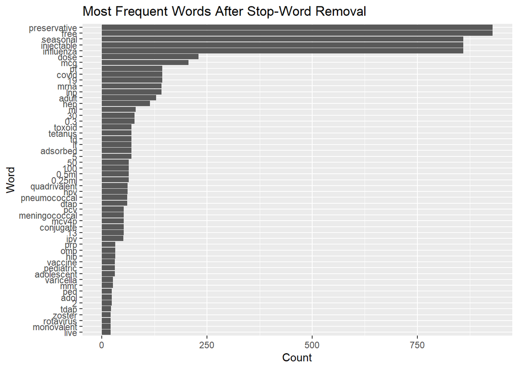

```r
word_freq_clean %>%
  filter(n > 20) %>%
  ggplot(aes(x = reorder(word, n), y = n)) +
  geom_col() +
  coord_flip() +
  labs(title = "Most Frequent Words After Stop-Word Removal",
       x = "Word",
       y = "Count")
```

**Create a Word Cloud**

A word cloud presents word frequencies visually, with more frequent words appearing larger. It offers a quick snapshot of key terms in the dataset.

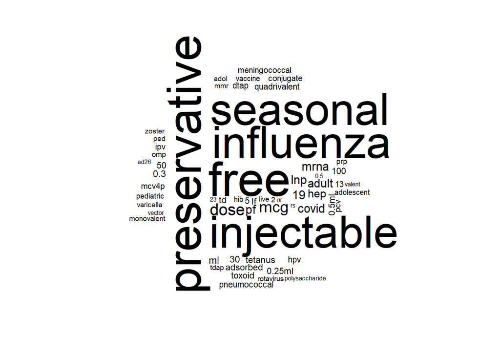

```r
par(mar = c(1, 1, 1, 1))  # reduce plot margins
wordcloud(words = word_freq_clean$word,
          freq = word_freq_clean$n,
          min.freq = 1,
          max.words = 100,
          random.order = FALSE)
```

**TF–IDF Analysis**

TF–IDF (Term Frequency–Inverse Document Frequency) highlights words that are common within a group but rare across groups. This helps identify terms that are contextually important for specific subgroups.

```r
# Example assumes a column called 'source_id' identifies individual documents

tfidf_result <- vaccination %>%
  select(source_id, DESCRIPTION) %>%
  unnest_tokens(word, DESCRIPTION) %>%
  anti_join(stop_words, by = "word") %>%
  count(source_id, word, sort = TRUE) %>%
  bind_tf_idf(word, source_id, n) %>%
  arrange(desc(tf_idf))

head(tfidf_result)
```

[output not shown]

**Bigrams and Trigrams (n-grams)**

Sometimes the context of words matters more than individual terms. N-grams (bigrams, trigrams, etc.) allow us to capture meaningful phrases instead of isolated words.

**Bigrams – two-word phrases**

```r
bigrams <- vaccination %>%
  unnest_tokens(bigram, DESCRIPTION, token = "ngrams", n = 2) %>%
  count(bigram, sort = TRUE)

head(bigrams)
```

```
                   bigram   n
1       preservative free 929
2      influenza seasonal 859
3 injectable preservative 859
4     seasonal injectable 859
5                    <NA> 185
6                covid 19 144
```

**Trigrams – three-word phrases**

```r
trigrams <- vaccination %>%
  unnest_tokens(trigram, DESCRIPTION, token = "ngrams", n = 3) %>%
  count(trigram, sort = TRUE)

head(trigrams)
```

```
                           trigram   n
1    influenza seasonal injectable 859
2     injectable preservative free 859
3 seasonal injectable preservative 859
4                             <NA> 319
5                      19 mrna lnp 142
6                    covid 19 mrna 142
```

**Create Categorical Variables from free and unstructured Text**

We use regular expressions to classify unstructured free-text values into consistent categories. This transformation is critical for summarising or modelling based on text. We can identify and map all words that contain a certain substring (like “covid” in “COVID-19”, “covid_19”, or “covid”). You can use str_detect() with a case-insensitive regular expression to filter your word frequency table.

```r
vaccination <- vaccination %>%
  mutate(vaccine_group = case_when(
    str_detect(DESCRIPTION, regex("covid|sars-cov-2", ignore_case = TRUE)) ~ "COVID-19",
    str_detect(DESCRIPTION, regex("influenza", ignore_case = TRUE)) ~ "Influenza",
    str_detect(DESCRIPTION, regex("hepatitis|hep a|hep b", ignore_case = TRUE)) ~ "Hepatitis",
    str_detect(DESCRIPTION, regex("hpv", ignore_case = TRUE)) ~ "HPV",
    str_detect(DESCRIPTION, regex("mmr", ignore_case = TRUE)) ~ "MMR",
    str_detect(DESCRIPTION, regex("dtap|tdap|tetanus|td \\(?adult\\)?", ignore_case = TRUE)) ~ "DTP group",
    str_detect(DESCRIPTION, regex("ipv", ignore_case = TRUE)) ~ "IPV",
    str_detect(DESCRIPTION, regex("hib", ignore_case = TRUE)) ~ "Hib",
    str_detect(DESCRIPTION, regex("meningococcal|mcv4", ignore_case = TRUE)) ~ "Meningococcal",
    str_detect(DESCRIPTION, regex("pneumococcal.*13", ignore_case = TRUE)) ~ "Pneumococcal PCV13",
    str_detect(DESCRIPTION, regex("pneumococcal.*23", ignore_case = TRUE)) ~ "Pneumococcal PPV23",
    str_detect(DESCRIPTION, regex("rotavirus", ignore_case = TRUE)) ~ "Rotavirus",
    str_detect(DESCRIPTION, regex("varicella", ignore_case = TRUE)) ~ "Varicella",
    str_detect(DESCRIPTION, regex("zoster", ignore_case = TRUE)) ~ "Zoster",
    TRUE ~ "Other"
  ))

# Frequency check

table(vaccination$vaccine_group)
```

```
          COVID-19          DTP group          Hepatitis                Hib
               144                152                114                 32
               HPV          Influenza                IPV      Meningococcal
                61                859                 51                 52
               MMR Pneumococcal PCV13 Pneumococcal PPV23          Rotavirus
                26                 52                  8                 21
         Varicella             Zoster
                26                 21
```

```r
# Grouping Values Using %in% Inside case_when()

vaccination <- vaccination %>%
  mutate(vacc_group3 = case_when(
    vaccine_group %in% c("COVID-19", "Influenza") ~ "Respiratory vaccines",
    vaccine_group %in% c("DTP group", "Hepatitis", "HPV", "Hib", "IPV",
                         "Meningococcal", "MMR") ~ "Childhood vaccines",
    TRUE ~ "Other"
  )) %>%
  select(-ENCOUNTER, -CODE)

head (vaccination)
```

```
                  DATE                              PATIENT
1 2016-04-10T09:04:48Z 30a6452c-4297-a1ac-977a-6a23237c7b46
2 2016-04-10T09:04:48Z 30a6452c-4297-a1ac-977a-6a23237c7b46
3 2016-04-10T09:04:48Z 30a6452c-4297-a1ac-977a-6a23237c7b46
4 2016-04-10T09:04:48Z 30a6452c-4297-a1ac-977a-6a23237c7b46
5 2002-10-29T19:07:21Z 34a4dcc4-35fb-6ad5-ab98-be285c586a4f
6 2005-11-01T19:07:21Z 34a4dcc4-35fb-6ad5-ab98-be285c586a4f
                                                   DESCRIPTION BASE_COST
1           Influenza  seasonal  injectable  preservative free       136
2 Td (adult)  5 Lf tetanus toxoid  preservative free  adsorbed       136
3                                                 Hep B  adult       136
4                                          meningococcal MCV4P       136
5           Influenza  seasonal  injectable  preservative free       136
6           Influenza  seasonal  injectable  preservative free       136
   vacc_date year    month vaccine_group          vacc_group3
1 2016-04-10 2016    April     Influenza Respiratory vaccines
2 2016-04-10 2016    April     DTP group   Childhood vaccines
3 2016-04-10 2016    April     Hepatitis   Childhood vaccines
4 2016-04-10 2016    April Meningococcal   Childhood vaccines
5 2002-10-29 2002  October     Influenza Respiratory vaccines
6 2005-11-01 2005 November     Influenza Respiratory vaccines
```

**Conclusion**

By combining the `tidytext`, `stringr`, and `dplyr` packages we converted messy free-text into structured data ready for analysis. This approach supports reproducible work, clearer insights, and more robust statistical modelling.

### **3.3 Factors and Labels**

- Creating factor levels and relabeling
- Applying labels with `label()` and `val_labels()`
- Descriptive summaries with `describe()`

In R, categorical variables can be represented as **factors** to support grouping, modeling, and formatting for reporting. Factor variables store both the value and its associated level label.

This section introduces key functions to:

- Convert variables into factors
- Rename or reorder levels for clarity
- Apply variable-level labels using `label()` or `var_label()`
- Assign value labels using `val_labels()` (e.g., `1 = Male`)
- Generate descriptive metadata summaries using `Hmisc::describe()`

**Value labels** are especially useful when numeric codes represent categorical responses. These can be shown in summaries or retained for export and display.

You can choose to display or hide value labels:

options(labelled::val_labels_visible = TRUE) # Show values like “1 = Male” options(labelled::val_labels_visible = FALSE) # Show only “Male”

**🔹 Summary of Functions for Working with Factors and Labels**

| **Task** | **Function** | **Description** |
| --- | --- | --- |
| Convert to factor | `as.factor(x)` | Convert a character or numeric variable into a factor |
| Reorder levels | `factor(x, levels = ...)` | Define a specific order for levels |
| Rename factor levels | `levels(x) <- c(...)` | Manually change the displayed names of factor levels |
| Recode with `forcats` | `fct_recode()`, `fct_relevel()` | Relabel, reorder, or collapse factor levels using tidyverse tools |
| Apply variable label | `label(x) <- "..."` or `var_label(x) <- "..."` | Assign a description to a variable |
| Apply value labels | `val_labels(x) <- c("Label" = code)` | Define how codes map to category names (e.g., `1 = Male`) |
| Retrieve labels | `label(x)`, `val_labels(x)` | View current labels or mappings |
| Generate summary with labels | `Hmisc::describe(df)` | Return a summary including variable names, labels, types, and distributions |

```r
# Select two categorical variables
vacc_factor <- vacc_pt_merged %>%
  select(gender, marital)

# Convert character to factor
vacc_factor <- vacc_factor %>%
  mutate(
    gender = factor(gender),
    marital = factor(marital)
  )

# Relabel factor levels using fct_recode()
vacc_factor <- vacc_factor %>%
  mutate(
    gender = fct_recode(gender, "Male" = "M", "Female" = "F"),
    marital = fct_recode(marital,
                         "Married" = "M",
                         "Divorced" = "D",
                         "Single" = "S",
                         "Widowed" = "W")
  )

tail(vacc_factor)
```

```
     gender marital
1614 Female  Single
1615 Female  Single
1616 Female  Single
1617 Female  Single
1618 Female  Single
1619 Female  Single
```

```r
# Assign variable labels
var_label(vacc_factor$gender) <- "Biological Sex"
var_label(vacc_factor$marital) <- "Marital Status"

# Assign value labels
vacc_factor$gender_chr <- as.character(vacc_factor$gender) # Convert factor to character
val_labels(vacc_factor$gender_chr) <- c("1" = "Male", "2" = "Female")


# View internal structure and label info
str(vacc_factor)
```

```
'data.frame':   1619 obs. of  3 variables:
 $ gender    : Factor w/ 2 levels "Female","Male": 2 2 2 2 2 2 2 2 2 2 ...
  ..- attr(*, "label")= chr "Biological Sex"
 $ marital   : Factor w/ 5 levels "","Divorced",..: 3 3 3 3 3 3 2 2 2 2 ...
  ..- attr(*, "label")= chr "Marital Status"
 $ gender_chr: chr+lbl [1:1619] Male  , Male  , Male  , Male  , Male  , Male  , Male ...
   ..@ labels: Named chr  "Male" "Female"
   .. ..- attr(*, "names")= chr [1:2] "1" "2"
```

```r
# Remove bad labels if needed:
var_label(vacc_factor$gender) <- NULL

# Remove temporary object
rm(vacc_factor)
```